[figure not shown]

[figure not shown]

[figure not shown]

# Model fit

### Assumption checks

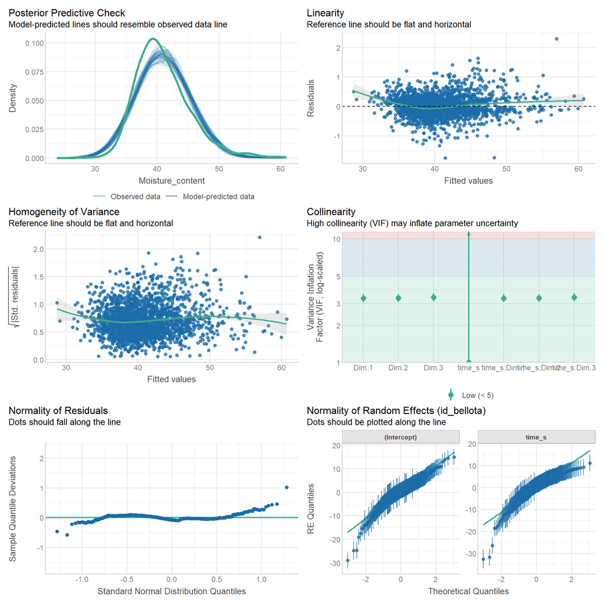

### Indices of model fit

| Metric | Value |
| --- | --- |
| AIC | 6193.2 |
| AICc | 6193.3 |
| BIC | 6260.8 |
| R2 (cond.) | 0.99 |
| R2 (marg.) | 0.31 |
| ICC | 0.98 |
| RMSE | 0.37 |
| Sigma | 0.47 |

For interpretation of performance metrics, please refer to [this documentation](https://easystats.github.io/performance/reference/model_performance.html).

# Parameter estimates

### Plot

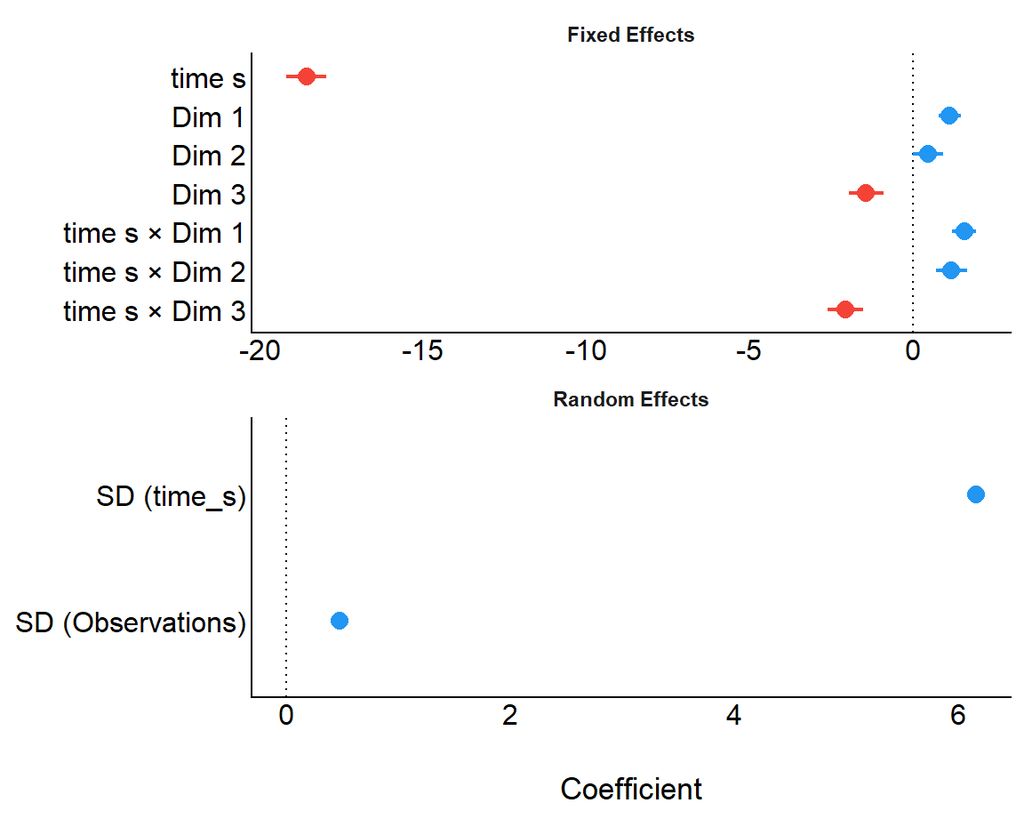

### Tabular summary

Fixed Effects

| Parameter | Coefficient | SE | 95% CI | z | p |
| --- | --- | --- | --- | --- | --- |
| (Intercept) | 24.09 | 0.30 | (23.49, 24.68) | 79.47 | < .001 |
| time s | -18.59 | 0.31 | (-19.20, -17.98) | -59.48 | < .001 |
| Dim 1 | 1.14 | 0.18 | (0.78, 1.49) | 6.30 | < .001 |
| Dim 2 | 0.47 | 0.23 | (9.60e-03, 0.92) | 2.00 | 0.045 |
| Dim 3 | -1.43 | 0.28 | (-1.97, -0.89) | -5.18 | < .001 |
| time s × Dim 1 | 1.58 | 0.19 | (1.21, 1.94) | 8.48 | < .001 |
| time s × Dim 2 | 1.19 | 0.24 | (0.72, 1.66) | 4.95 | < .001 |
| time s × Dim 3 | -2.06 | 0.28 | (-2.62, -1.51) | -7.27 | < .001 |

Random Effects

| Parameter | Coefficient |
| --- | --- |
| SD (Intercept: id_bellota) | 6.00 |
| SD (time_s: id_bellota) | 6.16 |
| Cor (Intercept~time_s: id_bellota) | 0.82 |
| SD (Residual) | 0.47 |

To find out more about table summary options, please refer to [this documentation](https://easystats.github.io/parameters/reference/model_parameters.html).

# Predicted Values

### Plot

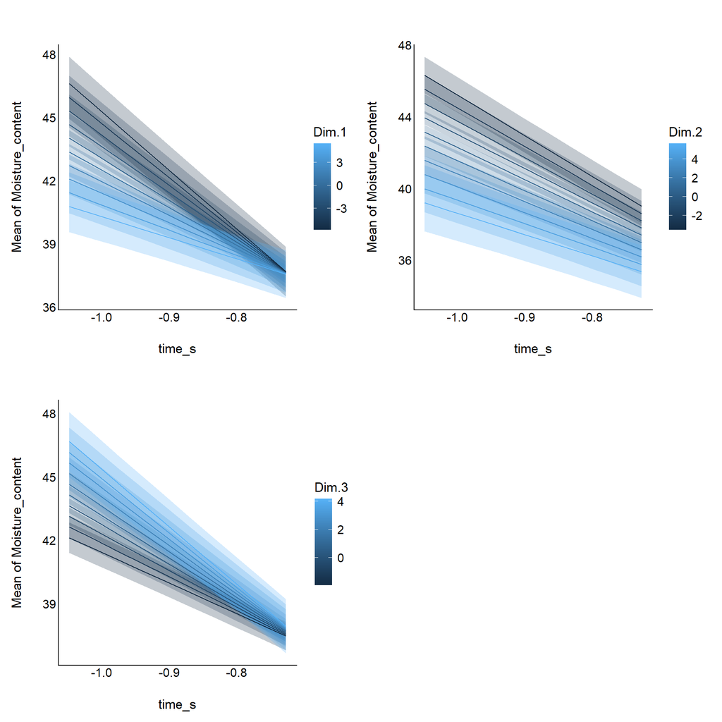

### Tabular summary

Estimated Marginal Means

| time_s | Dim.1 | Mean | SE | 95% CI | z |
| --- | --- | --- | --- | --- | --- |
| -1.05 | -5.77 | 46.61 | 0.65 | (45.33, 47.88) | 71.48 |
| -1.01 | -5.77 | 45.60 | 0.64 | (44.36, 46.85) | 71.63 |
| -0.98 | -5.77 | 44.60 | 0.62 | (43.38, 45.82) | 71.53 |
| -0.94 | -5.77 | 43.63 | 0.61 | (42.43, 44.83) | 71.16 |
| -0.90 | -5.77 | 42.63 | 0.60 | (41.44, 43.81) | 70.48 |
| -0.87 | -5.77 | 41.63 | 0.60 | (40.45, 42.80) | 69.48 |
| -0.83 | -5.77 | 40.65 | 0.60 | (39.48, 41.82) | 68.19 |
| -0.80 | -5.77 | 39.65 | 0.60 | (38.48, 40.82) | 66.55 |
| -0.76 | -5.77 | 38.65 | 0.60 | (37.48, 39.82) | 64.62 |
| -0.73 | -5.77 | 37.67 | 0.60 | (36.49, 38.86) | 62.48 |
| -1.05 | -4.52 | 45.96 | 0.52 | (44.93, 46.98) | 87.92 |
| -1.01 | -4.52 | 45.03 | 0.51 | (44.03, 46.03) | 88.21 |
| -0.98 | -4.52 | 44.10 | 0.50 | (43.12, 45.08) | 88.21 |
| -0.94 | -4.52 | 43.19 | 0.49 | (42.23, 44.16) | 87.87 |
| -0.90 | -4.52 | 42.26 | 0.48 | (41.31, 43.21) | 87.16 |
| -0.87 | -4.52 | 41.33 | 0.48 | (40.39, 42.27) | 86.05 |
| -0.83 | -4.52 | 40.43 | 0.48 | (39.49, 41.36) | 84.58 |
| -0.80 | -4.52 | 39.50 | 0.48 | (38.56, 40.43) | 82.69 |
| -0.76 | -4.52 | 38.57 | 0.48 | (37.63, 39.51) | 80.42 |
| -0.73 | -4.52 | 37.66 | 0.48 | (36.71, 38.61) | 77.89 |
| -1.05 | -3.26 | 45.31 | 0.40 | (44.53, 46.09) | 113.84 |
| -1.01 | -3.26 | 44.45 | 0.39 | (43.69, 45.21) | 114.38 |
| -0.98 | -3.26 | 43.59 | 0.38 | (42.85, 44.34) | 114.53 |
| -0.94 | -3.26 | 42.76 | 0.37 | (42.02, 43.49) | 114.25 |
| -0.90 | -3.26 | 41.90 | 0.37 | (41.17, 42.62) | 113.49 |
| -0.87 | -3.26 | 41.04 | 0.37 | (40.32, 41.75) | 112.22 |
| -0.83 | -3.26 | 40.20 | 0.36 | (39.49, 40.92) | 110.47 |
| -0.80 | -3.26 | 39.34 | 0.36 | (38.63, 40.06) | 108.17 |
| -0.76 | -3.26 | 38.48 | 0.37 | (37.77, 39.20) | 105.39 |
| -0.73 | -3.26 | 37.65 | 0.37 | (36.93, 38.37) | 102.26 |

[output cut: 70 more lines]

*Variable predicted: Moisture_content; Predictors modulated: time_s, Dim.1; Predictors averaged: Dim.2 (-0.02), Dim.3 (0.047), id_bellota*

Estimated Marginal Means

| time_s | Dim.2 | Mean | SE | 95% CI | z |
| --- | --- | --- | --- | --- | --- |
| -1.05 | -3.49 | 46.32 | 0.52 | (45.30, 47.34) | 88.97 |
| -1.01 | -3.49 | 45.50 | 0.51 | (44.50, 46.49) | 89.50 |
| -0.98 | -3.49 | 44.68 | 0.50 | (43.70, 45.65) | 89.73 |
| -0.94 | -3.49 | 43.88 | 0.49 | (42.92, 44.84) | 89.63 |
| -0.90 | -3.49 | 43.06 | 0.48 | (42.11, 44.00) | 89.16 |
| -0.87 | -3.49 | 42.24 | 0.48 | (41.30, 43.17) | 88.30 |
| -0.83 | -3.49 | 41.44 | 0.48 | (40.51, 42.37) | 87.07 |
| -0.80 | -3.49 | 40.62 | 0.48 | (39.69, 41.55) | 85.40 |
| -0.76 | -3.49 | 39.80 | 0.48 | (38.86, 40.73) | 83.35 |
| -0.73 | -3.49 | 39.00 | 0.48 | (38.05, 39.94) | 81.03 |
| -1.05 | -2.48 | 45.53 | 0.39 | (44.76, 46.29) | 116.54 |
| -1.01 | -2.48 | 44.75 | 0.38 | (44.00, 45.50) | 117.31 |
| -0.98 | -2.48 | 43.97 | 0.37 | (43.24, 44.70) | 117.69 |
| -0.94 | -2.48 | 43.21 | 0.37 | (42.49, 43.93) | 117.65 |
| -0.90 | -2.48 | 42.44 | 0.36 | (41.73, 43.15) | 117.12 |
| -0.87 | -2.48 | 41.66 | 0.36 | (40.96, 42.36) | 116.07 |
| -0.83 | -2.48 | 40.90 | 0.36 | (40.20, 41.60) | 114.54 |
| -0.80 | -2.48 | 40.13 | 0.36 | (39.43, 40.83) | 112.44 |
| -0.76 | -2.48 | 39.35 | 0.36 | (38.65, 40.05) | 109.84 |
| -0.73 | -2.48 | 38.59 | 0.36 | (37.89, 39.30) | 106.87 |
| -1.05 | -1.46 | 44.73 | 0.27 | (44.20, 45.27) | 163.83 |
| -1.01 | -1.46 | 44.00 | 0.27 | (43.48, 44.52) | 165.02 |
| -0.98 | -1.46 | 43.27 | 0.26 | (42.75, 43.78) | 165.68 |
| -0.94 | -1.46 | 42.55 | 0.26 | (42.05, 43.06) | 165.74 |
| -0.90 | -1.46 | 41.82 | 0.25 | (41.32, 42.31) | 165.12 |
| -0.87 | -1.46 | 41.08 | 0.25 | (40.59, 41.58) | 163.77 |
| -0.83 | -1.46 | 40.37 | 0.25 | (39.88, 40.86) | 161.73 |
| -0.80 | -1.46 | 39.64 | 0.25 | (39.15, 40.13) | 158.90 |
| -0.76 | -1.46 | 38.90 | 0.25 | (38.41, 39.39) | 155.35 |
| -0.73 | -1.46 | 38.19 | 0.25 | (37.69, 38.68) | 151.29 |

[output cut: 70 more lines]

*Variable predicted: Moisture_content; Predictors modulated: time_s, Dim.2; Predictors averaged: Dim.1 (0.024), Dim.3 (0.047), id_bellota*

Estimated Marginal Means

| time_s | Dim.3 | Mean | SE | 95% CI | z |
| --- | --- | --- | --- | --- | --- |
| -1.05 | -1.97 | 42.12 | 0.37 | (41.39, 42.85) | 113.58 |
| -1.01 | -1.97 | 41.60 | 0.36 | (40.89, 42.31) | 114.89 |
| -0.98 | -1.97 | 41.08 | 0.35 | (40.38, 41.77) | 115.84 |
| -0.94 | -1.97 | 40.57 | 0.35 | (39.88, 41.25) | 116.35 |
| -0.90 | -1.97 | 40.04 | 0.34 | (39.37, 40.72) | 116.41 |
| -0.87 | -1.97 | 39.52 | 0.34 | (38.85, 40.19) | 115.95 |
| -0.83 | -1.97 | 39.01 | 0.34 | (38.35, 39.68) | 114.98 |
| -0.80 | -1.97 | 38.49 | 0.34 | (37.83, 39.16) | 113.45 |
| -0.76 | -1.97 | 37.97 | 0.34 | (37.30, 38.64) | 111.39 |
| -0.73 | -1.97 | 37.46 | 0.34 | (36.79, 38.14) | 108.94 |
| -1.05 | -1.29 | 42.62 | 0.28 | (42.08, 43.17) | 153.06 |
| -1.01 | -1.29 | 42.05 | 0.27 | (41.52, 42.58) | 154.67 |
| -0.98 | -1.29 | 41.48 | 0.27 | (40.96, 42.00) | 155.77 |
| -0.94 | -1.29 | 40.92 | 0.26 | (40.41, 41.43) | 156.30 |
| -0.90 | -1.29 | 40.35 | 0.26 | (39.84, 40.85) | 156.19 |
| -0.87 | -1.29 | 39.77 | 0.26 | (39.27, 40.28) | 155.39 |
| -0.83 | -1.29 | 39.22 | 0.25 | (38.72, 39.72) | 153.91 |
| -0.80 | -1.29 | 38.64 | 0.25 | (38.14, 39.14) | 151.66 |
| -0.76 | -1.29 | 38.07 | 0.26 | (37.57, 38.57) | 148.73 |
| -0.73 | -1.29 | 37.51 | 0.26 | (37.01, 38.02) | 145.26 |
| -1.05 | -0.60 | 43.13 | 0.21 | (42.72, 43.53) | 208.79 |
| -1.01 | -0.60 | 42.50 | 0.20 | (42.11, 42.90) | 210.76 |
| -0.98 | -0.60 | 41.88 | 0.20 | (41.49, 42.27) | 212.04 |
| -0.94 | -0.60 | 41.27 | 0.19 | (40.89, 41.66) | 212.53 |
| -0.90 | -0.60 | 40.65 | 0.19 | (40.28, 41.03) | 212.15 |
| -0.87 | -0.60 | 40.03 | 0.19 | (39.65, 40.40) | 210.83 |
| -0.83 | -0.60 | 39.42 | 0.19 | (39.05, 39.79) | 208.59 |
| -0.80 | -0.60 | 38.80 | 0.19 | (38.43, 39.17) | 205.32 |
| -0.76 | -0.60 | 38.17 | 0.19 | (37.80, 38.54) | 201.10 |
| -0.73 | -0.60 | 37.57 | 0.19 | (37.19, 37.94) | 196.19 |

[output cut: 70 more lines]

*Variable predicted: Moisture_content; Predictors modulated: time_s, Dim.3; Predictors averaged: Dim.1 (0.024), Dim.2 (-0.02), id_bellota*

# Text reports

### Textual summary

We fitted a linear mixed model (estimated using ML and nlminb optimizer) to predict Moisture_content with time_s, Dim.1, Dim.2 and Dim.3 (formula: Moisture_content ~ time_s * (Dim.1 + Dim.2 + Dim.3)). The model included time_s as random effects (formula: ~time_s | id_bellota). The model’s total explanatory power is substantial (conditional R2 = 0.99) and the part related to the fixed effects alone (marginal R2) is of 0.31. The model’s intercept, corresponding to time_s = 0, Dim.1 = 0, Dim.2 = 0 and Dim.3 = 0, is at 24.09 (95% CI (23.49, 24.68), p < .001). Within this model:

- The effect of time s is statistically significant and negative (beta = -18.59, 95% CI (-19.20, -17.98), p < .001)
- The effect of Dim 1 is statistically significant and positive (beta = 1.14, 95% CI (0.78, 1.49), p < .001)
- The effect of Dim 2 is statistically significant and positive (beta = 0.47, 95% CI (9.60e-03, 0.92), p = 0.045)
- The effect of Dim 3 is statistically significant and negative (beta = -1.43, 95% CI (-1.97, -0.89), p < .001)
- The effect of time s × Dim 1 is statistically significant and positive (beta = 1.58, 95% CI (1.21, 1.94), p < .001)
- The effect of time s × Dim 2 is statistically significant and positive (beta = 1.19, 95% CI (0.72, 1.66), p < .001)
- The effect of time s × Dim 3 is statistically significant and negative (beta = -2.06, 95% CI (-2.62, -1.51), p < .001)

Standardized parameters were obtained by fitting the model on a standardized version of the dataset. 95% Confidence Intervals (CIs) and p-values were computed using a Wald z-distribution approximation. The model’s total explanatory power is substantial (conditional R2 = 0.99) and the part related to the fixed effects alone (marginal R2) is of 0.31

### Model information

[output not shown]

[output cut: 42 more lines]

````r
---
title: "Regression model summary from `{easystats}`"
output:
  flexdashboard::flex_dashboard:
    theme:
      version: 4
      # bg: "#101010"
      # fg: "#FDF7F7"
      primary: "#0054AD"
      base_font:
        google: Prompt
      code_font:
        google: JetBrains Mono
params:
  model: model
  check_model_args: check_model_args
  parameters_args: parameters_args
  performance_args: performance_args
---

```{r setup, include=FALSE}
library(flexdashboard)
library(easystats)

# Since not all regression model are supported across all packages, make the
# dashboard chunks more fault-tolerant. E.g. a model might be supported in
# `{parameters}`, but not in `{report}`.
#
# For this reason, `error = TRUE`
knitr::opts_chunk$set(
  error = TRUE,
  out.width = "100%"
)

# helper function for printing `{report}` outputs
bracket_to_parantheses <- function(text) {
  gsub("]", ")", gsub("[", "(", text, fixed = TRUE), fixed = TRUE)
}
```

```{r easydashboard-1}
# Get user-specified model data
model <- params$model

# Is it supported by `{easystats}`? Skip evaluation of the following chunks if not.
is_supported <- insight::is_model_supported(model)

if (!is_supported) {
  unsupported_message <- sprintf(
    "Unfortunately, objects of class `%s` are not yet supported in {easystats}.\n
    For a list of supported models, see `insight::supported_models()`.",
    class(model)[1]
  )
}
```


Model fit
=====================================

Column {data-width=700}
-----------------------------------------------------------------------

### Assumption checks

```{r check-model, eval=is_supported, fig.height=10, fig.width=10}
check_model_args <- c(list(model), params$check_model_args)
# add verbose, if not done yet
if (is.null(check_model_args$verbose)) check_model_args$verbose <- FALSE
tryCatch(
  {
    do.call(performance::check_model, check_model_args)
  },
  error = function(e) {
    cat(insight::format_message(
      "\nSomething did not work as expected. Please file an issue at {.url https://github.com/easystats/easystats/issues/} and post the following output:",
      paste0("\n`", e$message, "`")
    ))
  }
)
```

```{r easydashboard-2, eval=!is_supported}
cat(unsupported_message)
```

Column {data-width=300}
-----------------------------------------------------------------------

### Indices of model fit

```{r easydashboard-3, eval=is_supported}
# {performance}
performance_args <- c(list(model), params$performance_args)
# add verbose, if not done yet
if (is.null(performance_args$verbose)) performance_args$verbose <- FALSE
table_performance <- do.call(performance::performance, performance_args)
print_md(table_performance, layout = "vertical", caption = NULL)
```


```{r easydashboard-4, eval=!is_supported}
cat(unsupported_message)
```

For interpretation of performance metrics, please refer to <a href="https://easystats.github.io/performance/reference/model_performance.html" target="_blank">this documentation</a>.

Parameter estimates
=====================================

Column {data-width=550}
-----------------------------------------------------------------------

### Plot

```{r dot-whisker, eval=is_supported}
# `{parameters}`
parameters_args <- c(list(model), params$parameters_args)
# add verbose, if not done yet
if (is.null(parameters_args$verbose)) parameters_args$verbose <- FALSE
table_parameters <- do.call(parameters::parameters, parameters_args)

plot(table_parameters)
```


```{r easydashboard-5, eval=!is_supported}
cat(unsupported_message)
```

Column {data-width=450}
-----------------------------------------------------------------------

### Tabular summary

```{r easydashboard-6, eval=is_supported}
print_md(table_parameters, caption = NULL)
```


```{r easydashboard-7, eval=!is_supported}
cat(unsupported_message)
```

To find out more about table summary options, please refer to <a href="https://easystats.github.io/parameters/reference/model_parameters.html" target="_blank">this documentation</a>.


Predicted Values
=====================================

Column {data-width=600}
-----------------------------------------------------------------------

### Plot

```{r expected-values, eval=is_supported, fig.height=10, fig.width=10}
# {modelbased}
int_terms <- find_interactions(model, component = "conditional", flatten = TRUE)
con_terms <- find_variables(model)$conditional

if (is.null(int_terms)) {
  model_terms <- con_terms
} else {
  model_terms <- clean_names(int_terms)
  int_terms <- unique(unlist(strsplit(clean_names(int_terms), ":", fixed = TRUE)))
  model_terms <- c(model_terms, setdiff(con_terms, int_terms))
}

text_modelbased <- tryCatch(
  {
    lapply(unique(model_terms), function(i) {
      estimate_means(model, by = i, verbose = FALSE)
    })
  },
  error = function(e) {
    cat(insight::format_message(
      "\nSomething did not work as expected. Please file an issue at {.url https://github.com/easystats/easystats/issues/} and post the following output:",
      paste0("\n`", e$message, "`")
    ))
    NULL
  }
)

if (!is.null(text_modelbased)) {
  ggplot2::theme_set(theme_modern())
  # all_plots <- lapply(text_modelbased, function(i) {
  #   out <- do.call(visualisation_recipe, c(list(i), modelbased_args))
  #   plot(out) + ggplot2::ggtitle("")
  # })
  all_plots <- lapply(text_modelbased, function(i) {
    out <- visualisation_recipe(i, join_dots = FALSE, show_data = FALSE)
    plot(out) + ggplot2::ggtitle("")
  })

  see::plots(all_plots, n_columns = round(sqrt(length(text_modelbased))))
}
```


```{r easydashboard-8, eval=!is_supported}
cat(unsupported_message)
```

Column {data-width=400}
-----------------------------------------------------------------------

### Tabular summary

```{r easydashboard-9, eval=is_supported, results="asis"}
if (!is.null(text_modelbased)) {
  for (i in text_modelbased) {
    tmp <- print_md(i)
    tmp[length(tmp)] <- paste(insight::compact_character(strsplit(tmp[length(tmp)], "\n")[[1]]), collapse = "; ")
    print(tmp)
  }
}
```


```{r easydashboard-10, eval=!is_supported}
cat(unsupported_message)
```


Text reports
=====================================

Column {data-width=500}
-----------------------------------------------------------------------

### Textual summary

```{r easydashboard-11, eval=is_supported, results='asis', collapse=TRUE}
# {report}
text_report <- tryCatch(
  {
    report(model, verbose = FALSE)
  },
  error = function(e) {
    cat(insight::format_message(
      "\nSomething did not work as expected. Please file an issue at {.url https://github.com/easystats/easystats/issues/} and post the following output:",
      paste0("\n`", e$message, "`")
    ))
    NULL
  }
)


text_report_performance <- tryCatch(
  {
    report_performance(model, verbose = FALSE)
  },
  error = function(e) {
    cat(insight::format_message(
      "\nSomething did not work as expected. Please file an issue at {.url https://github.com/easystats/easystats/issues/} and post the following output:",
      paste0("\n`", e$message, "`")
    ))
    NULL
  }
)

if (!is.null(text_report)) {
  cat(bracket_to_parantheses(text_report))
  cat("\n")
}

if (!is.null(text_report_performance)) {
  cat(bracket_to_parantheses(text_report_performance))
}
```


```{r easydashboard-12, eval=!is_supported}
cat(unsupported_message)
```

Column {data-width=500}
-----------------------------------------------------------------------

### Model information

```{r easydashboard-13, eval=is_supported}
model_info_data <- insight::model_info(model, verbose = FALSE)
model_info_data <- datawizard::data_to_long(as.data.frame(insight::compact_list(model_info_data)))

DT::datatable(model_info_data)
```

```{r easydashboard-14, eval=!is_supported}
cat(unsupported_message)
```
````